# stream metabolizer SSS 021723 template

kaufman

2023-03-29

## 1. Install packages and loading libraries

If this is your first time running this code or streamMetabolizer, make sure to install the appropriate packages below. uncomment them in the chunk before Knitting.

```r
#install.packages(remotes); library(remotes)
# remotes::install_github('appling/unitted', force = TRUE)
# remotes::install_github("USGS-R/streamMetabolizer", force = TRUE)
#install.packages("rstan", dependencies = FALSE)
#install.packages(devtools)

# If you have trouble installing rstan, try the installation codes below:

#devtools::install_github("stan-dev/rstan", ref = "develop", subdir = "rstan/rstan", force = TRUE)
#install.packages("rstan", type = "source")

# Run the line below if you have trouble installing devtools
#devtools::install_github("stan-dev/rstan", ref = "develop", subdir = "rstan/rstan")
```

## 2. Setting up the data

Set working directory and read in the data and change units to match the needs of stream metabolizer. Note: Make sure to always double check that your date time column is in the date time format and not as character

```r
#-------------------------------------
SITE='S23'
#-------------------------------------

print("SITE: ")
```

```
## [1] "SITE: "
```

```r
SITE
```

```
## [1] "S23"
```

```r
osat<- function(temp, bp) {

  tstd<-log((298.15-temp) / (273.15 + temp))

  a0<-2.00907
  a1<-3.22014
  a2<-4.0501
  a3<-4.94457
  a4<- -0.256847
  a5<- 3.88767

  u<-10^(8.10765-(1750.286/(235+temp)))

  sato<-(exp(a0 + a1*tstd + a2*tstd^2 + a3*tstd^3 + a4*tstd^4+a5*tstd^5))*((bp-u)/(760-u))*1.42905
  sato
}

####function returns mm of Hg - not using because we have logged time-series BP
#bpcalc<- function(bpst, alt) {
#  bpst*25.4*exp((-9.80665*0.0289644*alt)/(8.31447*(273.15+15)))
#}
```

```r
#bp<-bpcalc(29.9, 489/3.28)# elevation at satus (alt in meters) #---------------------------------------------------------------------

data.path = "C:/Users/kauf093/OneDrive - PNNL/Spatial Study 2022/SSS_Data_Processing/4 - SSS_MiniDOT_with_Depth" #----------------
setwd(data.path)
 dat = read.csv(paste("SSS_MiniDOT_",SITE,"_with_Depth.csv",sep=''),header=T)

data.path="C:/Users/kauf093/OneDrive - PNNL/Documents/GitHub/gitlab/SSS_metabolism/initial_SM_testing"
setwd(data.path)
 K600estimates=read.csv('k600.csv',header=T)
 K600estimate<-K600estimates[K600estimates$Site_ID==SITE,3]


output.path="C:/Users/kauf093/OneDrive - PNNL/Documents/GitHub/gitlab/SSS_metabolism/StreamMetabolizer_runs/03292023"

 #---------------------------------------------------------------------------------------------
  file.name = paste(SITE,'_032923',sep='')
  #dat = na.omit(dat)
  #dat=dat[450:33311-300,] #-------------------------------------------------------------------------------------------------------------
 # Change date time format

#DOWNSAMPLE
samplingmins=15
dat = dat[seq(1, nrow(dat), samplingmins), ]

colnames(dat)[5]="Unix.Timestamp"
dat$timeUTC<-as_datetime(dat$Unix.Timestamp)
#dat$DATE_TIME = as.POSIXct(dat$DATE_TIME, format = "%Y-%m-%d %H:%M:%S", tz="Etc/GMT+8")
# Transform date time into solar time
dat$solar.time<-convert_UTC_to_solartime(dat$timeUTC, longitude= dat$Lon[1], time.type="mean solar") #----------------------------------
      # Longitude is from your field site

#trim out posibly-biofouled data after 8/29
dat<-dat[dat$solar.time<"2022-08-29 00:00:00",]


# Calculate in mg/L for much DO you would have in the water at the current saturation conditions
#      dat$DOsat_mg_per_L =(dat$Dissolved.Oxygen*100)/dat$Dosat_pct #can put calibration offset factor in here
#dat$Dissolved.Oxygen<-dat$Dissolved.Oxygen*1.018951498 #-----------------------------------------------------------------------
  # Reducing the number of decimals after performing the saturation calculations
#  dat$Dosat_mg_per_L = round(dat$DOsat_mg_per_L,2)

dat$light<- calc_light(dat$solar.time, latitude=dat$Lat[1], longitude=dat$Lon[1], max.PAR =2300, attach.units = F) #------------------
dat$DO.sat=osat(dat$TEMP_degreesC,dat$BP_mmhg)

# Selecting the data types that are needed for stream metabolizer and changing header names. Running the model with K600_pooling = normal does not require discharge input

     temp = dat
     dat = cbind.data.frame(temp$solar.time,temp$DO_mg_per_L,temp$DO.sat,temp$TEMP_degreesC,temp$light,temp$DEPTH_m)
     colnames(dat) = c("solar.time","DO.obs","DO.sat","temp.water","light","depth")
```

Check the number of cores you have in your computer. Based on the number that it prints, set the number of cores you want to dedicate to the metabolism run. It is recommended to set 2-4 cores less than you have in your computer to minimize the chances of R crashing. It is also recommended to select a pair number for your run.

```r
parallel::detectCores()
```

```
## [1] 20
```

## 3. Inspect Data

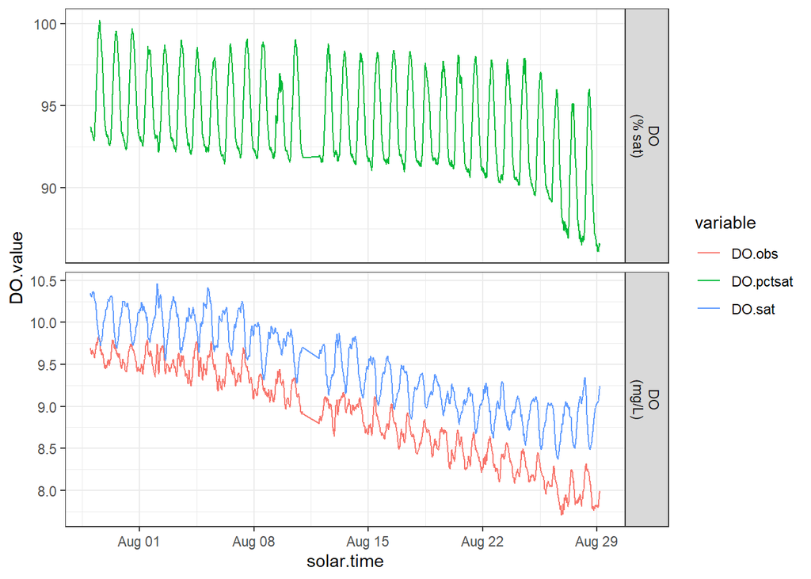

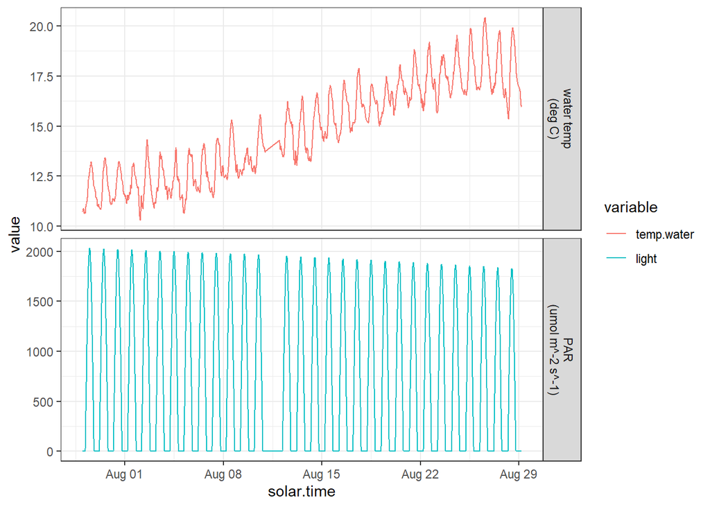

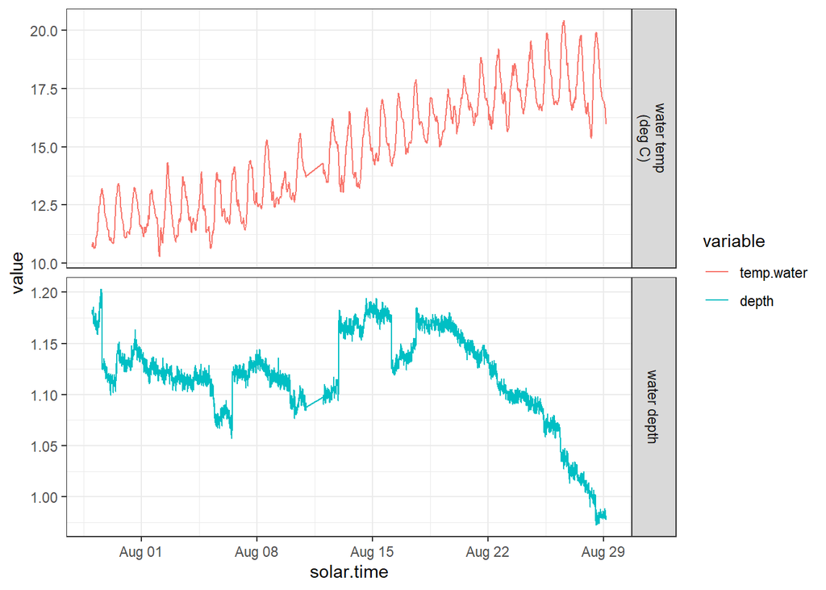

## 4. Configure the model

We will select a Bayesian model. Then we will configure the specs of the model depending on the needs of our run.  
You can play around with the number of iterations (e.g., 100 burnin iterations , also called warm up) and 50 saved steps. You can adjust the number of iterations based on the convergence of the convergence of the model.  
For example, you may start with 1000 and 500 and then up the numbers to 2000 and 1000 if the model results don’t seem to converge.

If you have already adjusted the number of steps multiple times and your model fits are still not good (e.g., negative GPP values) you might have to consider changing other specs in the model. Some examples of variables that you may change are: GPP_daily_lower = 0.01,ER_daily_upper = -0.01. However, you should consult the Help for more information.

Use the command plot_distribs if you want to observe the distribution of the specs if they were changed.

```r
# Set the model

bayes_name = mm_name(type='bayes',
                     pool_K600='normal',
                     err_obs_iid=TRUE,
                     err_proc_iid=TRUE)
bayes_name
```

```
## [1] "b_Kn_oipi_tr_plrckm.stan"
```

```r
 # Options for pool K600 are binned, linear, none and normal. If normal is specified, discharge doesn't need to be provided

# Changing the specs
bayes_specs = specs(bayes_name, K600_daily_meanlog_meanlog=log(K600estimate), K600_daily_meanlog_sdlog=0.7, K600_daily_sdlog_sigma=0.02, burnin_steps=1000,
                  saved_steps=1000,
                  n_cores=10)
```

## 5. Fit the model and save the results

Fitting the model might take hours or days depending on the dataset. Some times R crashes while you are running the model so you want to make sure to save your results in each run. Create an output folder inside of the path where you are storing the data, the output path will update automatically here once you change your data path in step 2.

Some key parameters to look at in the mm output are:  
- $daily (includes metabolism estimates) - $overall (includes error information) - $KQ_overall (included the relationship between K600-Q)

```r
mm = metab(bayes_specs, data=dat)#
#load("~/GitHub/gitlab/SSS_metabolism/initial_SM_testing/test_15min.RData")

#Extracting the data from the model output the outputs are in a S4
#class of data and you'll need to operators to extract the daily
#time series of estimates
#get_fit(mm) %>%
  #lapply(names)

# Saving key data
#output.path = paste0(data.output.path,"/Output/")
preds = mm@fit$daily
#str(preds)
write.csv(preds,paste0(output.path,"Results_",file.name,Sys.Date(),".csv"))

instant = mm@fit$inst
#str(instant)
write.csv(instant,paste0(output.path,"Instant_",file.name,Sys.Date(),".csv"))

Overall = mm@fit$overall
#str(Overall)
write.csv(Overall,paste0(output.path,"Overall_",file.name,Sys.Date(),".csv"))

KQ = mm@fit$KQ_overall
#str(KQ)
write.csv(KQ,paste0(output.path,"KQ_ovearll",file.name,Sys.Date(),".csv"))


#get_data(mm)# Shows a table with all the data + DO modeled
#get_data_daily(mm) #daily fitting data. It shows values for Q for now
#get_params(mm)
```

## 6. Inspect GPP, ER and K600

### Daily predictions of modeled GPP and ER

The goal is for the predictions (lines) and observations (points) to be very similar.

```
## # A tibble: 32 x 10
##    date         GPP GPP.l~1 GPP.u~2    ER ER.lo~3 ER.up~4 msgs.~5 warni~6 errors
##    <date>     <dbl>   <dbl>   <dbl> <dbl>   <dbl>   <dbl> <chr>   <chr>   <chr>
##  1 2022-07-28 NA     NA       NA    NA      NA      NA    "w    ~ ""      ""
##  2 2022-07-29  1.89   1.43     2.35 -5.52   -6.41   -4.68 "w    ~ ""      ""
##  3 2022-07-30  1.71   1.35     2.12 -5.50   -6.16   -4.75 "w    ~ ""      ""
##  4 2022-07-31  1.77   1.34     2.30 -5.43   -6.33   -4.65 "w    ~ ""      ""
##  5 2022-08-01  1.53   1.10     2.03 -5.43   -6.30   -4.56 "w    ~ ""      ""
##  6 2022-08-02  1.00   0.575    1.40 -4.94   -5.76   -3.99 "w    ~ ""      ""
##  7 2022-08-03  2.00   1.59     2.40 -6.30   -7.05   -5.41 "w    ~ ""      ""
##  8 2022-08-04  1.18   0.774    1.59 -5.12   -5.94   -4.31 "w    ~ ""      ""
##  9 2022-08-05  1.06   0.668    1.43 -5.85   -6.60   -4.90 "w    ~ ""      ""
## 10 2022-08-06  1.59   1.09     1.94 -5.86   -6.62   -4.77 "w    ~ ""      ""
## # ... with 22 more rows, and abbreviated variable names 1: GPP.lower,
## #   2: GPP.upper, 3: ER.lower, 4: ER.upper, 5: msgs.fit, 6: warnings
```

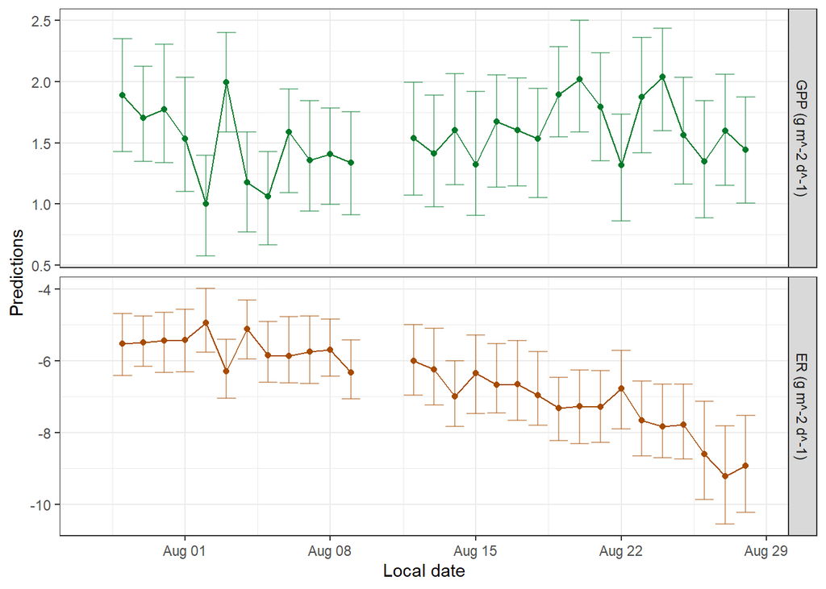

```
## # A tibble: 32 x 9
##    date       GPP.daily GPP.dai~1 ER.da~2 ER.da~3 K600.~4 K600.~5 warni~6 errors
##    <date>         <dbl>     <dbl>   <dbl>   <dbl>   <dbl>   <dbl> <chr>   <chr>
##  1 2022-07-28     NA       NA       NA     NA       NA     NA     overal~ "data~
##  2 2022-07-29      1.89     0.232   -5.53   0.455    8.35   0.545 overal~ ""
##  3 2022-07-30      1.71     0.200   -5.47   0.373    8.31   0.503 overal~ ""
##  4 2022-07-31      1.79     0.245   -5.44   0.441    8.35   0.534 overal~ ""
##  5 2022-08-01      1.54     0.248   -5.43   0.459    8.35   0.511 overal~ ""
##  6 2022-08-02      1.00     0.214   -4.92   0.447    8.34   0.560 overal~ ""
##  7 2022-08-03      1.99     0.200   -6.28   0.439    8.33   0.538 overal~ ""
##  8 2022-08-04      1.18     0.201   -5.13   0.409    8.41   0.532 overal~ ""
##  9 2022-08-05      1.07     0.202   -5.80   0.439    8.36   0.520 overal~ ""
## 10 2022-08-06      1.57     0.217   -5.81   0.466    8.36   0.527 overal~ ""
## # ... with 22 more rows, and abbreviated variable names 1: GPP.daily.sd,
## #   2: ER.daily, 3: ER.daily.sd, 4: K600.daily, 5: K600.daily.sd, 6: warnings
```

```
##         date          solar.time   DO.obs   DO.sat    depth temp.water light
## 1 2022-07-28 2022-07-28 23:57:38 9.692898 10.34595 1.178387     10.719     0
## 2 2022-07-28 2022-07-29 00:12:38 9.688948 10.33907 1.182771     10.737     0
## 3 2022-07-28 2022-07-29 00:27:38 9.675124 10.32361 1.182769     10.792     0
## 4 2022-07-28 2022-07-29 00:42:38 9.657350 10.31239 1.183089     10.828     0
## 5 2022-07-28 2022-07-29 00:57:38 9.649450 10.31575 1.180961     10.819     0
## 6 2022-07-28 2022-07-29 01:12:38 9.624763 10.30882 1.177347     10.855     0
##   DO.mod
## 1     NA
## 2     NA
## 3     NA
## 4     NA
## 5     NA
## 6     NA
```

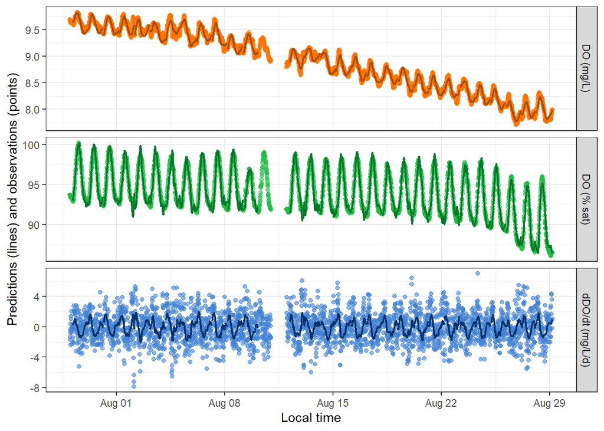

Ideally, good model results should have n_eff > 100 and Rhat < = 1.1. Below is a summary of these metrics for daily GPP, ER and K600.

```
## # A tibble: 32 x 6
##    GPP_Rhat ER_Rhat DO_R2_Rhat GPP_daily_Rhat ER_daily_Rhat K600_daily_Rhat
##       <dbl>   <dbl>      <dbl>          <dbl>         <dbl>           <dbl>
##  1    NA      NA         NA             NA            NA              NA
##  2     1.17    1.33       1.68           1.17          1.33            1.72
##  3     1.12    1.28       1.71           1.12          1.28            1.86
##  4     1.13    1.33       1.65           1.13          1.33            1.80
##  5     1.20    1.36       1.71           1.20          1.36            1.80
##  6     1.15    1.36       1.71           1.15          1.36            1.63
##  7     1.13    1.34       1.72           1.13          1.34            1.64
##  8     1.10    1.29       1.69           1.10          1.29            1.63
##  9     1.14    1.46       1.71           1.14          1.46            1.91
## 10     1.20    1.42       1.71           1.20          1.42            1.81
## # ... with 22 more rows
```

```
##    Min. 1st Qu.  Median    Mean 3rd Qu.    Max.    NA's
##   1.280   1.362   1.425   1.441   1.529   1.650       3
```

```
##    Min. 1st Qu.  Median    Mean 3rd Qu.    Max.    NA's
##   1.050   1.128   1.157   1.165   1.199   1.274       3
```

```
##    Min. 1st Qu.  Median    Mean 3rd Qu.    Max.    NA's
##   1.632   1.734   1.789   1.782   1.830   1.906       3
```

```
## # A tibble: 32 x 6
##    GPP_n_eff ER_n_eff DO_R2_n_eff GPP_daily_n_eff ER_daily_n_eff K600_daily_n_~1
##        <dbl>    <dbl>       <dbl>           <dbl>          <dbl>           <dbl>
##  1      NA      NA          NA               NA            NA              NA
##  2      18.1     7.67        7.73            18.1           7.67            3.63
##  3      28.1     6.34        8.04            28.1           6.34            3.15
##  4      37.0     6.08        8.23            37.0           6.08            3.23
##  5      15.1     7.06        7.73            15.1           7.06            3.50
##  6      38.1     7.27        7.85            38.1           7.27            3.83
##  7      27.8     6.04        7.79            27.8           6.04            3.62
##  8      36.5     8.25        7.91            36.5           8.25            4.01
##  9      24.5     4.36        7.81            24.5           4.36            3.00
## 10      17.1     5.67        7.90            17.1           5.67            3.43
## # ... with 22 more rows, and abbreviated variable name 1: K600_daily_n_eff
```

```
##    Min. 1st Qu.  Median    Mean 3rd Qu.    Max.    NA's
##   3.626   4.391   5.052   5.280   5.990   8.246       3
```

```
##    Min. 1st Qu.  Median    Mean 3rd Qu.    Max.    NA's
##   8.967  12.031  19.833  23.826  30.084  73.435       3
```

```
##    Min. 1st Qu.  Median    Mean 3rd Qu.    Max.    NA's
##   2.997   3.223   3.371   3.411   3.579   4.007       3
```

## 7. Inspect errors and their standard deviations

err_obs_iid_Rhat should have a value < 1.1. Additionally, in a conversation with Allison Appling she mentioned that they have seen pretty frequently err_obs_iid_sigma_Rhats much greater than 1.05, and mentioned it on the [JGR 2018 paper](https://doi.org/10.1002/2017JG004140). This is OK for that particular parameter because the values that the model continues to consider are usually quite similar in absolute magnitudes.

### Inspect err_obs_iid_Rhat and err_obs_iid_sigma_Rhat

```r
#err_obs_iid_Rhat
get_fit(mm)$inst %>%
  select(ends_with('Rhat'))
```

```
## # A tibble: 2,784 x 2
##    err_obs_iid_Rhat err_proc_iid_Rhat
##               <dbl>             <dbl>
##  1            1.00               1.04
##  2            1.00               1.04
##  3            1.00               1.04
##  4            0.999              1.05
##  5            0.999              1.06
##  6            0.999              1.07
##  7            0.999              1.08
##  8            1.00               1.08
##  9            1.00               1.08
## 10            1.00               1.10
## # ... with 2,774 more rows
```

```r
# err_obs_iid_sigma_Rhat. See comment from Appling
get_fit(mm)$overall %>%
  select(ends_with('Rhat'))
```

```
## # A tibble: 1 x 3
##   err_obs_iid_sigma_Rhat err_proc_iid_sigma_Rhat lp___Rhat
##                    <dbl>                   <dbl>     <dbl>
## 1                   1.89                    1.12      1.90
```

```r
get_fit(mm)$inst %>%
  select(ends_with('n_eff'))
```

```
## # A tibble: 2,784 x 2
##    err_obs_iid_n_eff err_proc_iid_n_eff
##                <dbl>              <dbl>
##  1             4865.               78.1
##  2             4624.               78.7
##  3             5044.               79.0
##  4             5397.               72.1
##  5             4652.               67.5
##  6             4751.               59.1
##  7             4900.               49.9
##  8             4681.               48.2
##  9             4677.               31.3
## 10             5804.               18.4
## # ... with 2,774 more rows
```

```r
get_fit(mm)$overall %>%
  select(ends_with('n_eff'))
```

```
## # A tibble: 1 x 3
##   err_obs_iid_sigma_n_eff err_proc_iid_sigma_n_eff lp___n_eff
##                     <dbl>                    <dbl>      <dbl>
## 1                    6.97                     41.0       6.93
```

```r
summary(instant$err_obs_iid_n_eff)
```

```
##    Min. 1st Qu.  Median    Mean 3rd Qu.    Max.
##    3232    4450    4698    4704    4953    7016
```

```r
summary(instant$err_obs_iid_Rhat)
```

```
##    Min. 1st Qu.  Median    Mean 3rd Qu.    Max.
##  0.9991  0.9996  0.9998  0.9999  1.0002  1.0034
```

```r
summary(instant$err_proc_iid_n_eff)
```

```
##    Min. 1st Qu.  Median    Mean 3rd Qu.    Max.    NA's
##   9.439  69.992 102.914 118.994 162.988 711.712      29
```

```r
summary(instant$err_proc_iid_Rhat)
```

```
##    Min. 1st Qu.  Median    Mean 3rd Qu.    Max.    NA's
##   1.002   1.026   1.044   1.048   1.062   1.181      29
```

```r
summary(Overall$err_obs_iid_sigma_Rhat)# There is only one err_obs_iid_sigma_Rhat per run
```

```
##    Min. 1st Qu.  Median    Mean 3rd Qu.    Max.
##   1.894   1.894   1.894   1.894   1.894   1.894
```

```r
summary(Overall$err_proc_iid_sigma_Rhat)
```

```
##    Min. 1st Qu.  Median    Mean 3rd Qu.    Max.
##   1.122   1.122   1.122   1.122   1.122   1.122
```

```r
summary(Overall$err_obs_iid_sigma_n_eff)
```

```
##    Min. 1st Qu.  Median    Mean 3rd Qu.    Max.
##   6.971   6.971   6.971   6.971   6.971   6.971
```

```r
summary(Overall$err_proc_iid_sigma_n_eff)
```

```
##    Min. 1st Qu.  Median    Mean 3rd Qu.    Max.
##   41.01   41.01   41.01   41.01   41.01   41.01
```

## 8. Inspect the relationships between variables

### Relationship between K600 and Q: we do not have Q in this experiment, so use depth as a proxy

The first step is to plot K600 and depth, this relationship should be linear??. To find this relationship we have to calculate the mean depth per day and then plot against K600.

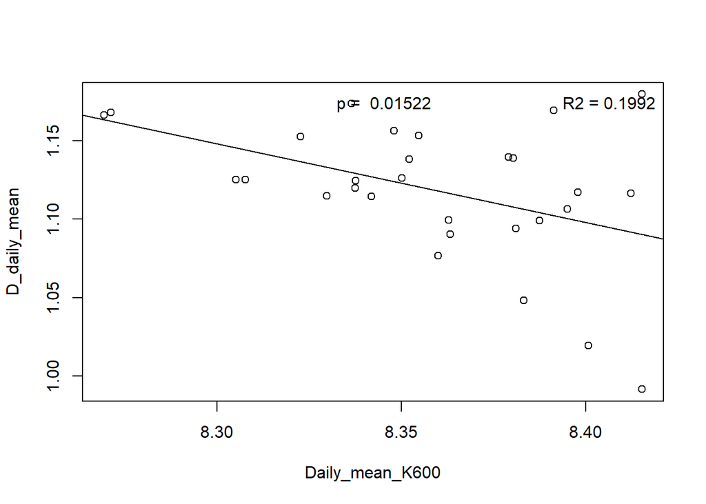

```r
    dat$solar.time = as.Date(dat$solar.time)
    meanDday = aggregate(dat["depth"],by = dat["solar.time"],mean)
    meanDday=meanDday[meanDday$solar.time %in% preds$date,]
    K600D = lm(preds$K600_daily_mean~meanDday$depth)

    plot(preds$K600_daily_mean,meanDday$depth,
         ylab="D_daily_mean",xlab="Daily_mean_K600")
    abline(lm(meanDday$depth~preds$K600_daily_mean))
      legend("topright", bty="n", legend=paste("R2 =", format(summary(K600D)$r.squared, digits=4)))
legend("top", bty="n", legend=paste("p = ", format(summary(K600D)$coefficients[8], digits=4)))
```

```r
    summary(K600D)
```

```
##
## Call:
## lm(formula = preds$K600_daily_mean ~ meanDday$depth)
##
## Residuals:
##       Min        1Q    Median        3Q       Max
## -0.070028 -0.018445  0.000121  0.021400  0.081189
##
## Coefficients:
##                Estimate Std. Error t value Pr(>|t|)
## (Intercept)      8.8032     0.1718  51.238   <2e-16 ***
## meanDday$depth  -0.3977     0.1535  -2.592   0.0152 *
## ---
## Signif. codes:  0 '***' 0.001 '**' 0.01 '*' 0.05 '.' 0.1 ' ' 1
##
## Residual standard error: 0.03572 on 27 degrees of freedom
##   (3 observations deleted due to missingness)
## Multiple R-squared:  0.1992, Adjusted R-squared:  0.1696
## F-statistic: 6.718 on 1 and 27 DF,  p-value: 0.01522
```

### Relationship between K600 and ER

This relationship is key. Bob Hall says: My primary metric is to look for covariance between ER and K. These have high equifinality which means that any combination of ER or K can provide an equally good fit to the model. If these covary strongly (r=0.6 or higher) then that may not be good for examining controls on variation in ER. If you find **no relationship**, that is a **very good** thing. If there is a relationship, that is if R2 is high, it means that the model can’t parse reaeration from respiration. In this case, ER and K600 are working in opposite for O2, so ideally there is no relationship in the model outputs.

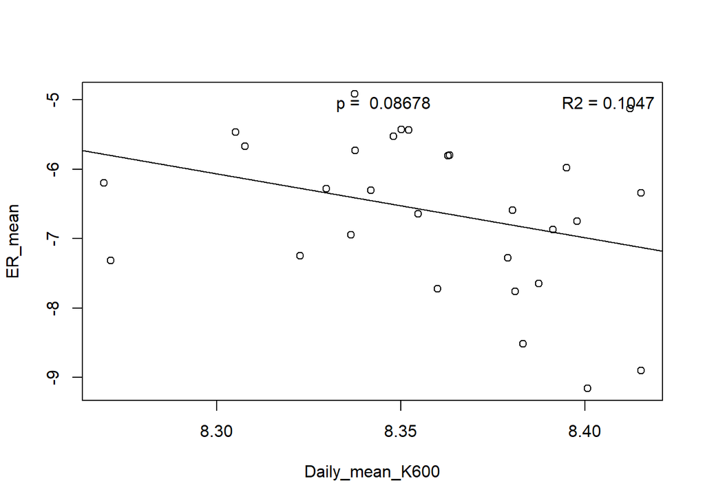

```r
K600ER = lm(K600_daily_mean~ER_mean, data=preds)

    plot(preds$K600_daily_mean,preds$ER_mean,ylab="ER_mean",xlab="Daily_mean_K600")
    abline(lm(ER_mean~K600_daily_mean, data=preds))
    legend("topright", bty="n", legend=paste("R2 =", format(summary(K600ER)$r.squared, digits=4)))
legend("top", bty="n", legend=paste("p = ", format(summary(K600ER)$coefficients[8], digits=4)))
```

```r
 summary(K600ER)
```

```
##
## Call:
## lm(formula = K600_daily_mean ~ ER_mean, data = preds)
##
## Residuals:
##       Min        1Q    Median        3Q       Max
## -0.095251 -0.012999  0.005139  0.017221  0.070875
##
## Coefficients:
##              Estimate Std. Error t value Pr(>|t|)
## (Intercept)  8.282958   0.042927 192.956   <2e-16 ***
## ER_mean     -0.011403   0.006416  -1.777   0.0868 .
## ---
## Signif. codes:  0 '***' 0.001 '**' 0.01 '*' 0.05 '.' 0.1 ' ' 1
##
## Residual standard error: 0.03777 on 27 degrees of freedom
##   (3 observations deleted due to missingness)
## Multiple R-squared:  0.1047, Adjusted R-squared:  0.07158
## F-statistic: 3.159 on 1 and 27 DF,  p-value: 0.08678
```

### Relationship between K600 and GPP

High GPP is needed to estimate K well, so K should get more variable as GPP decreases.

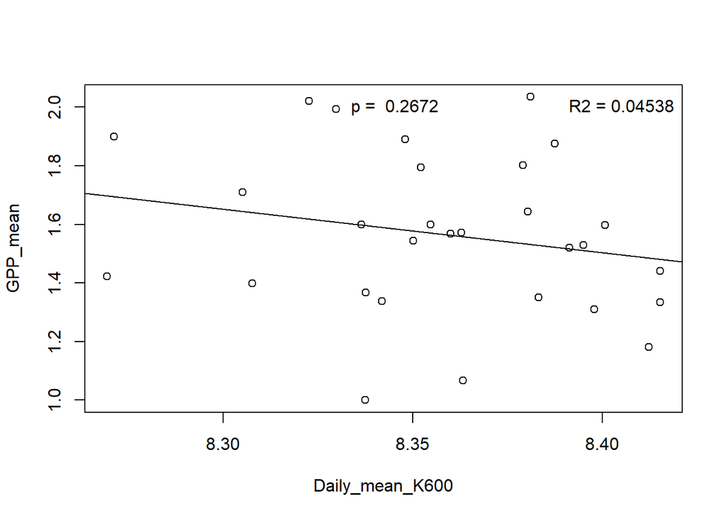

```r
K600GPP = lm(GPP_mean~K600_daily_mean, data=preds)


    plot(preds$K600_daily_mean,preds$GPP_mean,ylab="GPP_mean",xlab="Daily_mean_K600")
    abline(lm(GPP_mean~K600_daily_mean, data=preds))
    legend("topright", bty="n", legend=paste("R2 =", format(summary(K600GPP)$r.squared, digits=4)))
legend("top", bty="n", legend=paste("p = ", format(summary(K600GPP)$coefficients[8], digits=4)))
```

```r
    summary(K600GPP)
```

```
##
## Call:
## lm(formula = GPP_mean ~ K600_daily_mean, data = preds)
##
## Residuals:
##      Min       1Q   Median       3Q      Max
## -0.59624 -0.19720  0.00465  0.20424  0.50367
##
## Coefficients:
##                 Estimate Std. Error t value Pr(>|t|)
## (Intercept)       14.015     10.989   1.275    0.213
## K600_daily_mean   -1.490      1.315  -1.133    0.267
##
## Residual standard error: 0.2727 on 27 degrees of freedom
##   (3 observations deleted due to missingness)
## Multiple R-squared:  0.04538,    Adjusted R-squared:  0.01002
## F-statistic: 1.283 on 1 and 27 DF,  p-value: 0.2672
```

### Time series daily mean K600

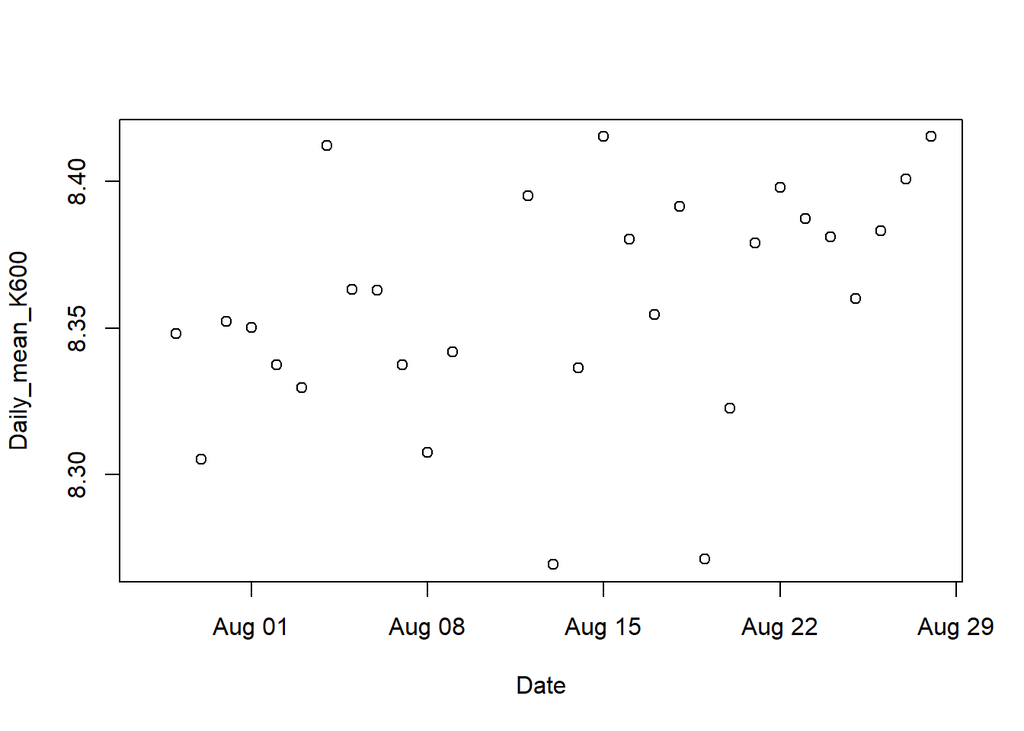

```r
    preds$date = as.Date(preds$date)

    plot(preds$date,preds$K600_daily_mean,
         xlab="Date",ylab="Daily_mean_K600")
```